# Mel Schwan DDS HW 3

Mel Schwan

5/26/2019

## Live session Unit 03 assignment

```r
library(dplyr)
```

```r
library(ggplot2)
library(ggpubr)
theme_set(theme_pubr())
#Question 2 part a.
passengers <- read.csv(file="titanic.csv",head=TRUE)
#Question 2 part b.
passenger_sex <- passengers %>%
  group_by(Sex) %>%
  summarise(counts = n())
passenger_sex
```

```
## # A tibble: 2 x 2
##   Sex    counts
##   <fct>   <int>
## 1 female    314
## 2 male      577
```

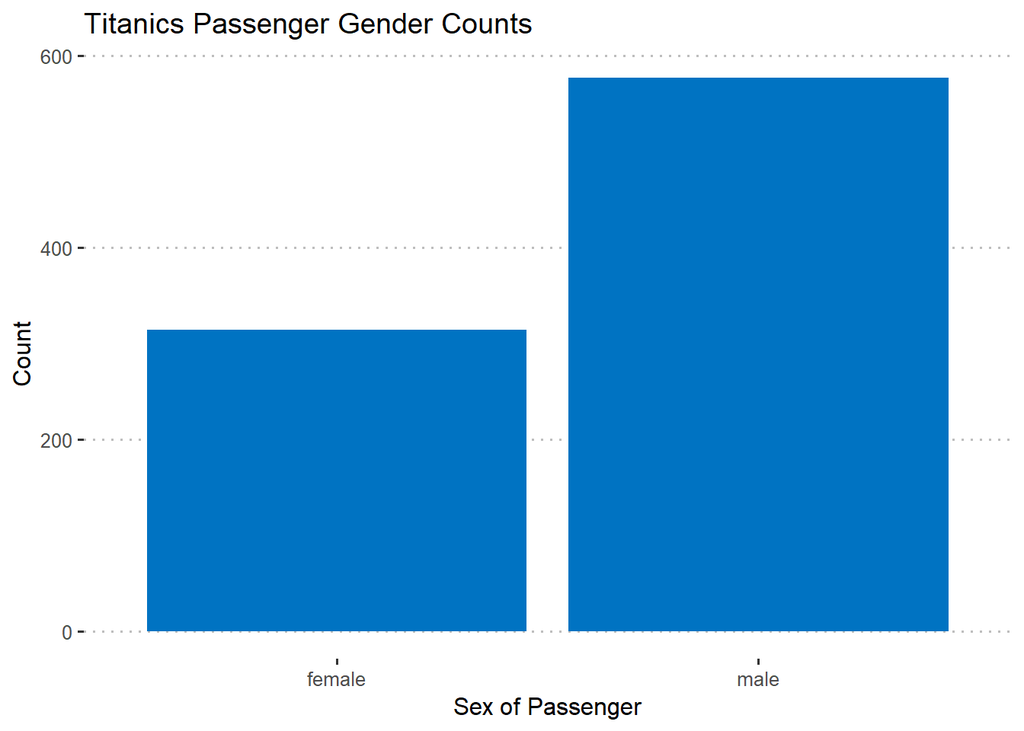

```r
ggplot(data = passengers, aes(Sex)) +
  geom_bar(fill = "#0073C2FF") +
  labs(title = "Titanics Passenger Gender Counts", x = "Sex of Passenger", y="Count") +
  theme_pubclean()
```

```r
# Question 2 part c
x <- passengers$Age+passengers$Fare

data_means <- data.frame(passengers$Age, passengers$Fare, passengers$Survived)
apply(data_means, MARGIN = 2, FUN = mean, na.rm =TRUE, trim = .0)
```

```
##      passengers.Age     passengers.Fare passengers.Survived
##          29.6991176          32.2042080           0.3838384
```

3. Function Building (30 points): You research sleep and just got your first data set. Later, you’ll have another dataset with the same column names, so you want to create a helper function that you can analyze this dataset and the next. Load sleep_data_01.csv (found at http://talklab.psy.gla.ac.uk/L1_labs/lab_1/homework/index.html). Questions 3A through 3D should be answered in function(x){}. 3E can be outside of the function.
   1. Create objects for the median Age, the minimum and maximum Duration of sleep, and the mean and standard deviation of the Rosenberg Self Esteem scale (RSES). You may need to specify a few options like in Problem 2 and live session.
   2. Create a data.frame object called report: it should consist of the median age, the RSES mean and standard deviation respectively divided by five (since there are five questions and these scores are summed), and the range of Duration (the statistical definition of range; it should be a single number.)
   3. Change the column names of this data.frame to MedianAge, SelfEsteem, SE_SD, and DurationRange.
   4. Round the report to at most 2 digits: leave this as the closing line to the function.
   5. Finally, run the function on your sleep data to show the output.

```r
library(dplyr)
library(ggplot2)
library(ggpubr)
theme_set(theme_pubr())

#Question 3 part a.

sleep_study <- read.csv(file="sleep_data_01.csv",head=TRUE)

#Question 3 part b,c,d
#Function for taking the sleep study data and calculating certain statistics
sleep_function <- function(sleep_study) {

    med_age = median(sleep_study$Age, na.rm = TRUE)
    min_time = min(sleep_study$Duration, na.rm =TRUE)
    max_time = max(sleep_study$Duration, na.rm =TRUE)
    rses_mean = mean(sleep_study$RSES,na.rm =TRUE)
    rses_std = sd(sleep_study$RSES,na.rm =TRUE)
    sleep_stats<- list("med_age" = med_age, "min_time" = min_time, "max_time" = max_time, "rses_mean" = rses_mean, "rses_std" = rses_std)
    age = sleep_stats$med_age/5
    rsesmean = sleep_stats$rses_mean/5
    rsessd = sleep_stats$rses_std/5
    range_dur = sleep_stats$max_time-sleep_stats$min_time
    report_df = data.frame('MeianAge'=age, 'SelfEsteem'=rsesmean, 'SE_SD'=rsessd, 'DurationRange'=range_dur)
    report_df = round_df(report_df, digits = 2)
    report_df

}
#Function for rounding contents of the dataframe
round_df <- function(df, digits) {
  nums <- vapply(df, is.numeric, FUN.VALUE = logical(1))

  df[,nums] <- round(df[,nums], digits = digits)

  return(df)
}

#Question 3 part e.
sleep_function(sleep_study)
```

```
##   MeianAge SelfEsteem SE_SD DurationRange
## 1      2.8       3.62  1.24             7
```

4. FiveThirtyEight Data (30 points): Navigate on GitHub to https://github.com/rudeboybert/fivethirtyeight and read README.md. It will include everything you need.
   1. Install the fivethirtyeight package.
   2. In the listing of Data sets in package ‘fivethirtyeight,’ assign the 22nd data set to an object ‘df.’
   3. Use a more detailed list of the data sets to write out the URL in a comment to the related news story.
   4. Using R command(s), give the dimensions and column names of this data frame.

```r
# Get index of data from fivethirtyeight
congress_age_df=fivethirtyeight::congress_age

data_file_df = read.csv(file = 'C:\\Users\\eu360a\\Google Drive\\#Masters\\Doing Data Science\\R programming\\data-master\\index.csv' ,head=TRUE)
data_url = data_file_df$dataset_url[145]
data_url
```

```
## [1] https://github.com/fivethirtyeight/data/tree/master/congress-age
## 128 Levels: https://github.com/fivethirtyeight/actblue-analysis ...
```

#Use the following url to find out more information on the congressional datafile

[output not shown]

```r
dim.data.frame(congress_age_df)
```

```
## [1] 18635    13
```

```r
colnames(congress_age_df)
```

```
##  [1] "congress"   "chamber"    "bioguide"   "firstname"  "middlename"
##  [6] "lastname"   "suffix"     "birthday"   "state"      "party"
## [11] "incumbent"  "termstart"  "age"
```

5. Data Summary (30 points): Use your newly assigned data frame from question 4 for this question.
   1. Write an R command that gives you the column names of the data frame. Right after that, write one that counts the number of columns but not rows. Hint: The number should match one of your numbers in Question 1d for dimensions.
   2. Generate a count of each unique major_category in the data frame. I recommend using libraries to help. To be clear, this should look like a matrix or data frame containing the major_category and the frequency it occurs in the dataset. Assign it to major_count.
   3. To make things easier to read, put par(las=2) before your plot to make the text perpendicular to the axis. Make a barplot of major_count. Make sure to label the title with something informative (check the vignette if you need), label the x and y axis, and make it any color other than grey. Assign the major_category labels to their respective bar. Flip the barplot horizontally so that bars extend to the right, not upward. All of these options can be done in a single pass of barplot(). Note: It’s okay if it’s wider than the preview pane.
   4. Write the fivethirtyeight data to a csv file. Make sure that it does not have row labels.

```r
# Column names
names_col <- colnames(congress_age_df)
ncol(congress_age_df)
```

```
## [1] 13
```

```r
data_file_df = read.csv(file = 'C:\\Users\\eu360a\\Google Drive\\#Masters\\Doing Data Science\\R programming\\data-master\\index.csv' ,head=TRUE)
data_file_df$dataset_url[22]
```

```
## [1] https://github.com/fivethirtyeight/data/tree/master/senate-forecast-2018
## 128 Levels: https://github.com/fivethirtyeight/actblue-analysis ...
```

Parts b. and c. ran out of time and did not fully understand

```r
#Question 5 part d.
write.csv(congress_age_df, 'fivethirtyeightdata.csv')
```

6. Codebook a.Start a new repository on GitHub for your SMU MSDS homework. On your local device, make sure there is a directory for Homework at the minimum; you are welcome to add whatever you would like to this repo in addition to your requirements here.
   2. Create a README.md file which explains the purpose of the repository, the topics included, the sources for the material you post, and contact information in case of questions. Remember, the one in the root directory should be general. You are welcome to make short READMEs for each assignment individually in other folders.
   3. In one (or more) of the nested directories, post your RMarkdown script, HTML file, and data from ‘fivethirtyeight.’ Make sure that in your README or elsewhere that you credit fivethirtyeight in some way.
   4. In your RMarkdown script, please provide the link to this GitHub so the grader can see it.

   Repository at https://github.com/schwan1/DDS